# pa5

Michele Goldin

4/3/2018

## Load data

```r
library(tidyverse)
langdata <- read.csv('./data_raw/pa_5_data/lang_data_raw.csv', header = TRUE, sep = ',')

head(langdata)
```

```
##                 id    iq motivation prof
## 1   p01_male_older 97.04       1.47 0.67
## 2 p02_female_older 91.51       1.31 0.46
## 3   p03_male_older 97.18       1.48 0.55
## 4 p04_female_older 91.47       1.31 0.49
## 5   p05_male_older 96.04       1.44 0.59
## 6 p06_female_older 93.79       1.37 0.62
```

```r
#View(langdata)
```

## Tidy data

Create a new column called age and a new column called sex (though it may not be used in analysis later)

```r
tidylangdata <- langdata %>%
  separate(., col = id, into = c('id', 'sex', 'age'), sep="_")

#View(tidylangdata)
```

## Create new variable

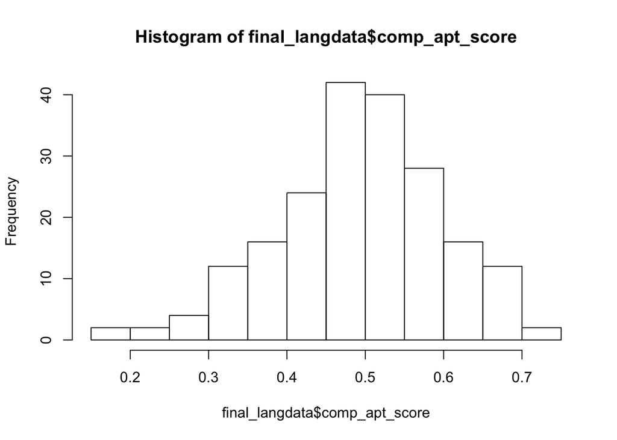

```r
final_langdata <- tidylangdata%>%
  mutate(., comp_apt_score = log(iq / 80) + log(motivation))

#View(final_langdata)

#Check normality

hist(final_langdata$comp_apt_score)
```

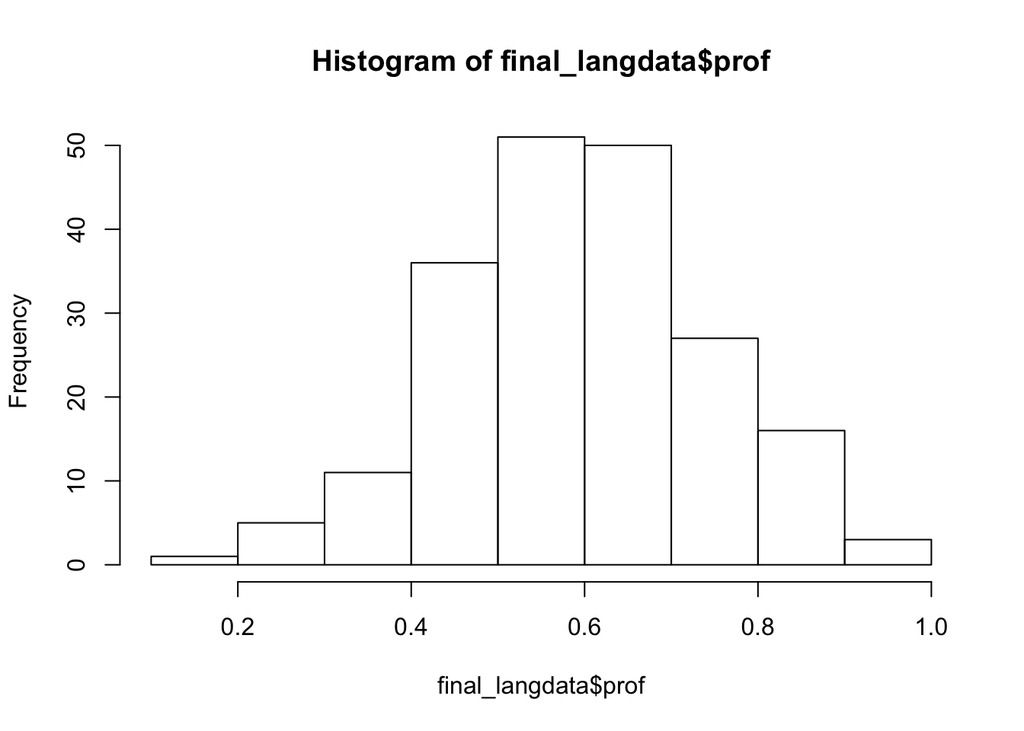

```r
hist(final_langdata$prof)
```

## Descriptive statistics

Calculate the mean and SD proficiency score and comp_apt_score by age

```r
final_langdata %>%
group_by(., age) %>%
summarize(., mean_prof = mean(prof), SD_prof = sd(prof), mean_comp = mean(comp_apt_score), SD_comp = sd(comp_apt_score)) %>%
knitr::kable(., format = 'markdown', digits = 2)
```

| age | mean_prof | SD_prof | mean_comp | SD_comp |
| --- | --- | --- | --- | --- |
| older | 0.54 | 0.14 | 0.49 | 0.1 |
| younger | 0.67 | 0.13 | 0.49 | 0.1 |

As we can see in the table, the mean proficiency score is higher for younger learners than for older learners, but both groups have the same mean language aptitude score.

## Plot the data

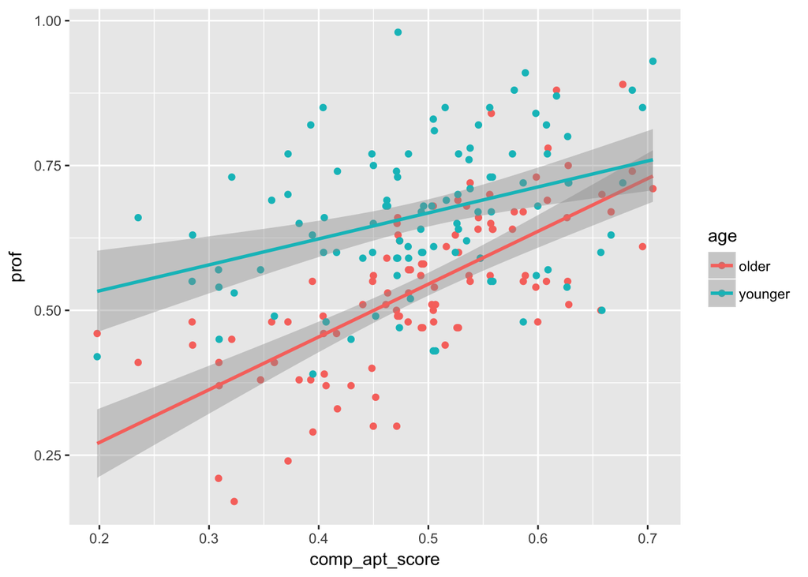

```r
final_langdata%>%
  ggplot(., aes (x = comp_apt_score, y = prof, color = age)) +
      geom_point() +
      geom_smooth(method = lm)
```

Figure 1 shows the proficiency and language aptitude scores of the older and younger learner groups. Overall, younger learners have higher proficiency scores than older learners and proficiency seems to increase with higher language aptitude scores. However, older learners with higher language aptitude also have higher proficiency scores.

## Nested model comparison

```r
mod_full <- lm(prof ~ age + comp_apt_score + age:comp_apt_score, data = final_langdata)
mod_int <- lm(prof ~ age + comp_apt_score, data = final_langdata)
mod_comp <- lm(prof ~ age, data = final_langdata)
mod_age <- lm(prof ~ comp_apt_score, data = final_langdata)
mod_null <- lm(prof ~ 1, data = final_langdata)

anova(mod_int, mod_full)
```

```
## Analysis of Variance Table
##
## Model 1: prof ~ age + comp_apt_score
## Model 2: prof ~ age + comp_apt_score + age:comp_apt_score
##   Res.Df    RSS Df Sum of Sq      F   Pr(>F)
## 1    197 2.4404
## 2    196 2.3240  1   0.11638 9.8147 0.001997 **
## ---
## Signif. codes:  0 '***' 0.001 '**' 0.01 '*' 0.05 '.' 0.1 ' ' 1
```

```r
anova(mod_comp, mod_int)
```

```
## Analysis of Variance Table
##
## Model 1: prof ~ age
## Model 2: prof ~ age + comp_apt_score
##   Res.Df    RSS Df Sum of Sq      F    Pr(>F)
## 1    198 3.4444
## 2    197 2.4404  1     1.004 81.049 < 2.2e-16 ***
## ---
## Signif. codes:  0 '***' 0.001 '**' 0.01 '*' 0.05 '.' 0.1 ' ' 1
```

```r
anova(mod_age, mod_int)
```

```
## Analysis of Variance Table
##
## Model 1: prof ~ comp_apt_score
## Model 2: prof ~ age + comp_apt_score
##   Res.Df    RSS Df Sum of Sq      F    Pr(>F)
## 1    198 3.2354
## 2    197 2.4404  1   0.79506 64.181 9.741e-14 ***
## ---
## Signif. codes:  0 '***' 0.001 '**' 0.01 '*' 0.05 '.' 0.1 ' ' 1
```

```r
anova(mod_int, mod_age) #change the order in order to get the F statistic
```

```
## Analysis of Variance Table
##
## Model 1: prof ~ age + comp_apt_score
## Model 2: prof ~ comp_apt_score
##   Res.Df    RSS Df Sum of Sq      F    Pr(>F)
## 1    197 2.4404
## 2    198 3.2354 -1  -0.79506 64.181 9.741e-14 ***
## ---
## Signif. codes:  0 '***' 0.001 '**' 0.01 '*' 0.05 '.' 0.1 ' ' 1
```

```r
anova(mod_null, mod_int, mod_comp, mod_age) #keep interaction, age is significant; comp is not significant
```

```
## Analysis of Variance Table
##
## Model 1: prof ~ 1
## Model 2: prof ~ age + comp_apt_score
## Model 3: prof ~ age
## Model 4: prof ~ comp_apt_score
##   Res.Df    RSS Df Sum of Sq      F    Pr(>F)
## 1    199 4.2395
## 2    197 2.4404  2   1.79908 72.615 < 2.2e-16 ***
## 3    198 3.4444 -1  -1.00402 81.049 < 2.2e-16 ***
## 4    198 3.2354  0   0.20896
## ---
## Signif. codes:  0 '***' 0.001 '**' 0.01 '*' 0.05 '.' 0.1 ' ' 1
```

```r
summary(mod_full)
```

```
##
## Call:
## lm(formula = prof ~ age + comp_apt_score + age:comp_apt_score,
##     data = final_langdata)
##
## Residuals:
##      Min       1Q   Median       3Q      Max
## -0.24110 -0.06781  0.00171  0.07496  0.32423
##
## Coefficients:
##                           Estimate Std. Error t value Pr(>|t|)
## (Intercept)                0.08963    0.05266   1.702   0.0903 .
## ageyounger                 0.35436    0.07447   4.758 3.78e-06 ***
## comp_apt_score             0.91121    0.10447   8.722 1.17e-15 ***
## ageyounger:comp_apt_score -0.46286    0.14775  -3.133   0.0020 **
## ---
## Signif. codes:  0 '***' 0.001 '**' 0.01 '*' 0.05 '.' 0.1 ' ' 1
##
## Residual standard error: 0.1089 on 196 degrees of freedom
## Multiple R-squared:  0.4518, Adjusted R-squared:  0.4434
## F-statistic: 53.85 on 3 and 196 DF,  p-value: < 2.2e-16
```

## Results

The language data were analyzed using a general linear model to test the effect of proficiency as a function of age and language aptitude. Proficiency was set as the dependent variable and age (younger/older) and language aptitude were set as the predictors. Older learners were dummy coded as the referent group. Main effects and the age by language aptitude interaction were assessed using nested model comparisons. Experiment-wise alpha was set at 0.05.